# Higher mitochondrial oxidative capacity is the primary molecular differentiator in muscle of rats with high and low intrinsic cardiorespiratory fitness

Johanna Fleischman

2023-07-19

## Calculate Differentially Expressed Genes and Pathways using DESeq2

For this analysis, I used RNA-Seq data sets from 2 experiments:

- Water fed (control) male and female HCR and LCR from a feeding experiment at the University of Toledo (Exps 3235 and 3510)
- Saline-infused (control) male and female HCR and LCR from an infusion experiment at the University of Michigan (Exp 6548)

The experiment-adjusted HCR/LCR line effect is determined using the formula $Gene \sim Experiment + Line$ in in male rats and female rats separately

The line-adjusted sex affect is calculated from the infusion experiment only (Exp 6548) using the formula $Gene \sim Line + Sex$

```r
# Verify that all samples are the same and are in the same order
if(!all(colnames(expected.counts) %in% rownames(expected.counts.meta)) &&
   !all(colnames(expected.counts) == rownames(expected.counts.meta))){

  warning("Count and metadata dataframes not ordered - ordering now")
  reorder_idx <- match(rownames(expected.counts.meta),colnames(expected.counts))
  expected.counts <- expected.counts[, reorder_idx]

  if(!all(colnames(expected.counts) %in% rownames(expected.counts.meta)) &&
     !all(colnames(expected.counts) == rownames(expected.counts.meta))){
    stop("Problem with count and metadata dataframes")
  }
}

all_transcriptomic_data <- list(Male_Line_Effect = list(),
                                Female_Line_Effect = list(),
                                Sex_Effect = list())

for(i in c("Male_Line_Effect","Female_Line_Effect","Sex_Effect")) {

  print(paste0("----------Starting ", i,"----------"))

  # Define contrast
  if(i == "Male_Line_Effect"){
    expected.counts.meta.temp <- expected.counts.meta %>%
      dplyr::filter(Sex == "Male")
    expected.counts.temp <- expected.counts[,rownames(expected.counts.meta.temp)]
    temp_form <- "~ Exp + Line"
    temp_cont <- c("Line","HCR","LCR")

  } else if(i == "Female_Line_Effect") {
    expected.counts.meta.temp <- expected.counts.meta %>%
      dplyr::filter(Sex == "Female")
    expected.counts.temp <- expected.counts[,rownames(expected.counts.meta.temp)]
    temp_form <- "~ Exp + Line"
    temp_cont <- c("Line","HCR","LCR")

  } else {
    expected.counts.meta.temp <- expected.counts.meta %>%
      dplyr::filter(Exp == "6548")
    expected.counts.temp <- expected.counts[,rownames(expected.counts.meta.temp)]
    temp_form <- "~ Line + Sex"
    temp_cont <- c("Sex","Male","Female")

  }

  # Set up differential expression experiment design
  # For each sex, we want the Line effect, adjusted for Experiment
  dds <- DESeq2::DESeqDataSetFromMatrix(countData = expected.counts.temp,
                                colData = expected.counts.meta.temp,
                                design = stats::as.formula(temp_form))

  # Only keep genes with > 10 counts across all samples to remove noise
  keep <- rowSums( counts(dds) ) >= 10
  dds <- dds[keep,]

  # Run DESeq command on the summarized experiment file
  dds <- DESeq2::DESeq(dds)

  # Extract results for Line contrast and set up data frame
  res <- DESeq2::results(dds, contrast=temp_cont) %>%
    as.data.frame()
  res <- cbind("gene_id" = row.names(res), res)

  # Bind to other usable gene names for pathway and MitoCarta analysis
  degs <- right_join(gene_name_conversion, res, by = "gene_id")

  # Pathway analysis
  sigvals <- as.numeric(degs$pvalue)
  geneids <- as.numeric(degs$entrezgene_id)

  pathways <- LRpath(sigvals, geneids, min.g=10, max.g=NA, sig.cutoff=0.05,
                    functionalCategories="KEGG",
                    odds.min.max=c(0.001,0.5), species="rno")

  all_transcriptomic_data[[i]] <- list(DEGs = degs, Pathways = pathways)
}
```

```
## [1] "----------Starting Male_Line_Effect----------"
## Analyzing KEGG categories...........................
## [1] "----------Starting Female_Line_Effect----------"
## Analyzing KEGG categories...........................
## [1] "----------Starting Sex_Effect----------"
## Analyzing KEGG categories...........................
```

## Unbiased Differential Gene Expression Analysis

### Volcano Plots (Figure 1A)

The data shown in the volcano plots are differential gene expression analyses performed separately for males and females using DESeq2 as above. Differentially expressed genes were determined for each sex, instead of combining all the animals, because sex and experiment were confounded as batches for one experiment but not the other.

Genes that are colored have an adjusted p-value $< 0.05$

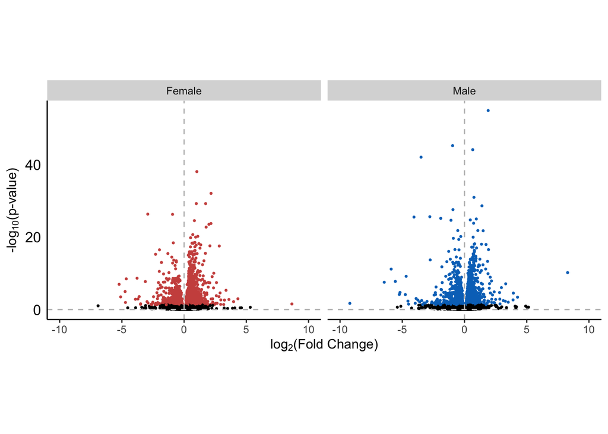

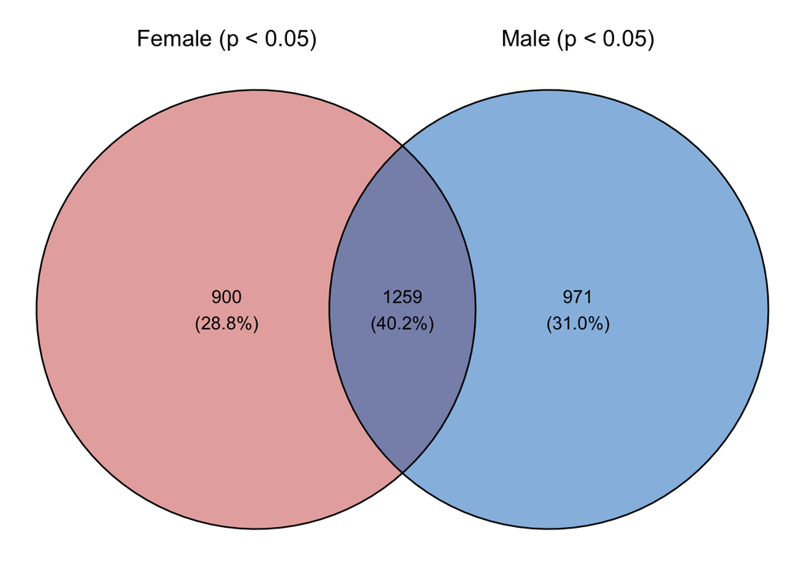

### Pathway Analysis (Figure 1B)

Pathways were determined using the datasets generated for the volcano plots. I continued to pursue a by-sex approach given the fact that (1) we have sex-wise mitochondrial respiration data, and (2) the Venn diagram of overlapping significant genes indicated that only $40.2\%$ of the significant genes overlapped.

For pathway analysis, I used LRPath (through the R CLEAN package) which accepts the entire list of p-values and Entrez IDs for differential gene expression data sets. I observed KEGG pathways. In the following plot, I have plotted the odds ratios of the pathways after filtering for pathways that had an FDR $<0.05$ for males or females. Odds ratios $>1$ indicate that the pathway is upregulated in HCR rats.

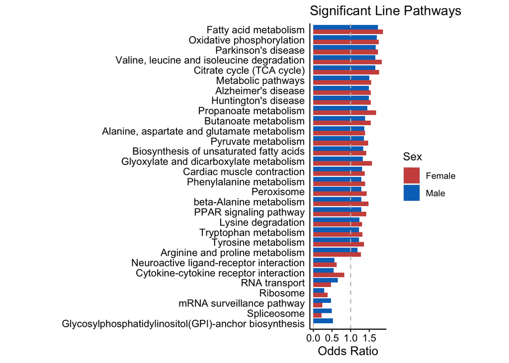

## MitoCarta Analysis (Figure 2)

Next, I took a closer look at specifically mitochondrial genes. This targeted approach was warranted given that our unbiased approach indicated that the most significantly regulated pathways in both males and females were mitochondrial metabolic pathways. Because the pathways regulated by Line were nearly identical between males and females, I combine the male and female data sets here and perform mitochondrial gene set filtering with the following steps:

```r
# Merge male and female gene expression data frames and reassign column names
all_dfs <- all_transcriptomic_data[["Female_Line_Effect"]][["DEGs"]] %>%
  dplyr::select(c("gene_id","entrezgene_id","external_gene_name","description","log2FoldChange","padj")) %>%
  dplyr::left_join(., all_transcriptomic_data[["Male_Line_Effect"]][["DEGs"]][,c("gene_id","log2FoldChange","padj")], by = "gene_id") %>%
  dplyr::rename(log2FC_F = log2FoldChange.x, padj_F = padj.x, log2FC_M = log2FoldChange.y, padj_M = padj.y)

#####################################################
##                                                 ##
##    User-friendly functions for performing       ##
##    MitoCarta pathway assignment and analysis    ##
##    on a provided list of gene symbols, IDs,     ##
##   or Uniprot IDs (see function documentation).  ##
##                                                 ##
#####################################################

# Extract MitoCarta data from website; available species are mouse and human
mitocarta_data <- extract_mitocarta_data(species = "mouse",
                                         gene_id_type = "gene_symbol"
                                         )
```

```
## Extracting MitoCarta3.0 dataset
```

```r
# If providing a list of NCBI gene names, optionally check if any missing names
# are listed as a synonym by MitoCarta. Recommended.
gene_names_checked <- check_mitocarta_synonyms(
  gene_names = all_dfs$external_gene_name,
  mitocarta_data = mitocarta_data
  )
```

```
## 30 symbol names found from synonym IDs and are being replaced
```

```
## 2954 symbol names from given gene names have no MitoCarta match and will be returned as NAs
```

```r
# Assigned pathways to gene names using mitocarta_data_formatted
mitocarta_data <- assign_mitocarta_pathways(
  gene_names = gene_names_checked$mitocarta_id,
  mitocarta_data = mitocarta_data
  )
```

```
## 15463 genes that were not assigned a mitochondrial pathway will be removed
```

```
## 85 pathways annotated with '0' will be removed
```

```r
#####################################################

# General steps for merging dataframes
data_all <- gene_names_checked %>%
  rename(external_gene_name = given_id, Name = mitocarta_id) %>%
  right_join(., all_dfs, by = "external_gene_name") %>%
  left_join(., mitocarta_data[["Assigned_Pathways"]], by = "Name")

# Add mean logFC between male and female
# Perform Fisher method to combine adjusted p-values for female and male
data_all$log2FC_mean <- sapply(1:nrow(data_all), function(x) {
  mean(c(data_all$log2FC_F[x],data_all$log2FC_M[x]))}
  )

data_all$padj_fisher_combined <- sapply(1:nrow(data_all), function(x) {
  ifelse(!is.na(data_all$padj_F[x])&&(!is.na(data_all$padj_F[x])), metap::sumlog(c(data_all$padj_F[x],data_all$padj_F[x]))$p, NA)}
  )

# At this point in analysis, data_all object was saved as a .csv to view gene expression
# data and pathway assignment for all genes

# Specific steps taken for my data put into MitoCarta analysis
# Remove any genes with non equal direction of effect or no pathway assignment
# Filter for combined p-value (Fisher) < 0.05
data_filtered <- data_all %>%
  filter(!is.na(Main.Path)) %>%
  filter(padj_fisher_combined < 0.05) %>%
  filter(sign(log2FC_M) == sign(log2FC_F))

print(paste0("Of ",length(mitocarta_data$MitoCarta_MitoGenes$Symbol)," mitochondrial genes annotated by MitoCarta, ",
             table(mitocarta_data$MitoCarta_MitoGenes$Symbol %in%
                     na.omit(gene_names_checked$mitocarta_id))[[2]], " (",
             round(table(mitocarta_data$MitoCarta_MitoGenes$Symbol %in%
                           na.omit(gene_names_checked$mitocarta_id))[[2]]/length(mitocarta_data$MitoCarta_MitoGenes$Symbol),3)*100, "%) of these genes were present in the provided dataset"))
```

```
## [1] "Of 1140 mitochondrial genes annotated by MitoCarta, 1049 (92%) of these genes were present in the provided dataset"
```

```r
print(paste0("This filter results in a dataset with ", length(unique(data_filtered$gene_id)), " mitochondrial genes that are significantly differentially expressed between HCR and LCR when sexes are combined"))
```

```
## [1] "This filter results in a dataset with 453 mitochondrial genes that are significantly differentially expressed between HCR and LCR when sexes are combined"
```

### Quantifying the number and percentage of genes in pathways

Here, we plot the number of genes that filter into main pathways annotated by MitoCarta. Note that genes can be assigned to multiple pathways. This functions also calculates the number of genes that MitoCarta assigns to each sub pathway, so that the percent of the pathway represented in a filtered dataset can be calculated. For the percent calculations here, the number of genes that MitoCarta assigns to each pathway, regardless of it’s presence in our original dataset, is used as the denominator.

In the percent graphs, the color indicates the mean log2(Fold Change) of the genes included in that pathway.

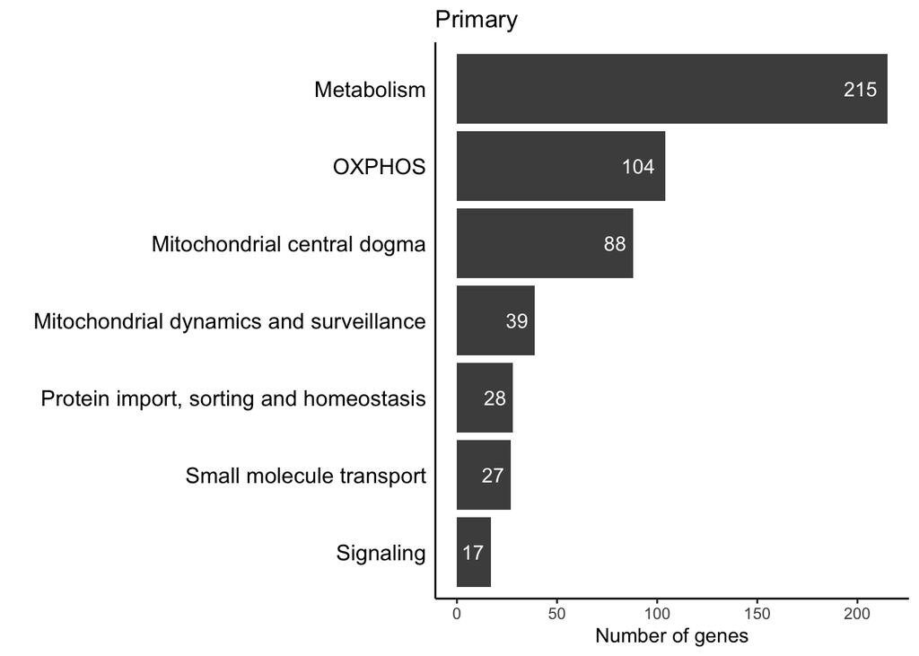

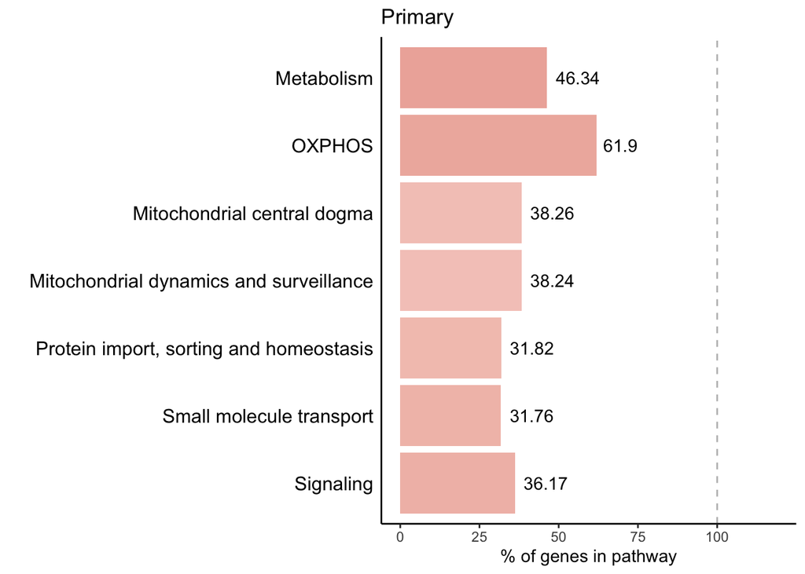

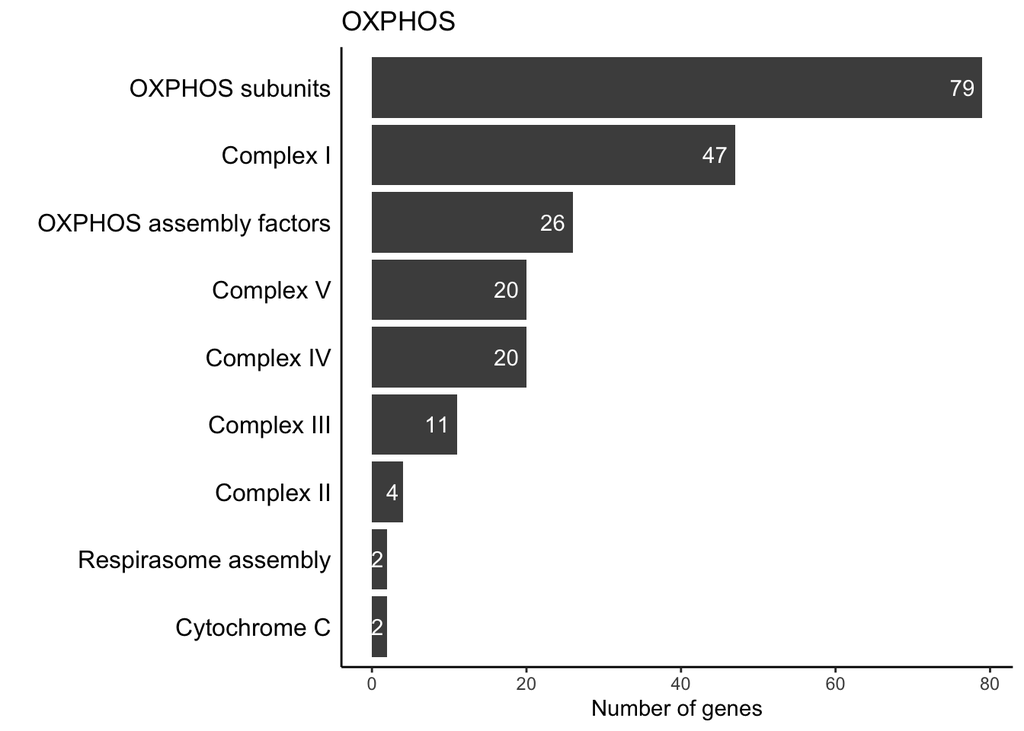

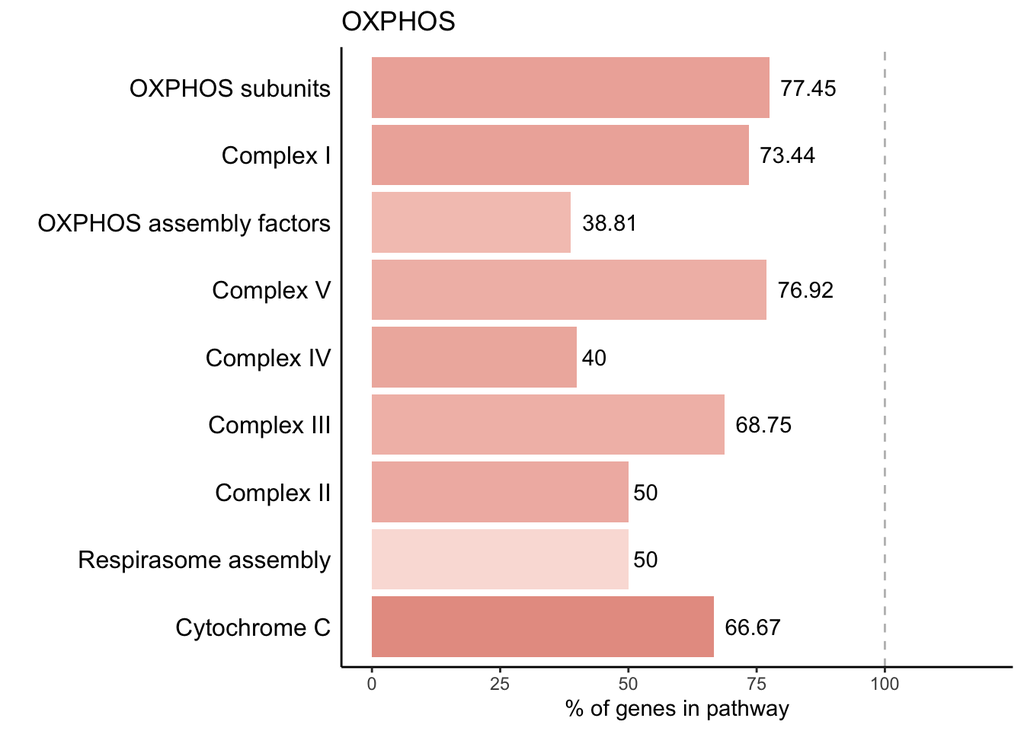

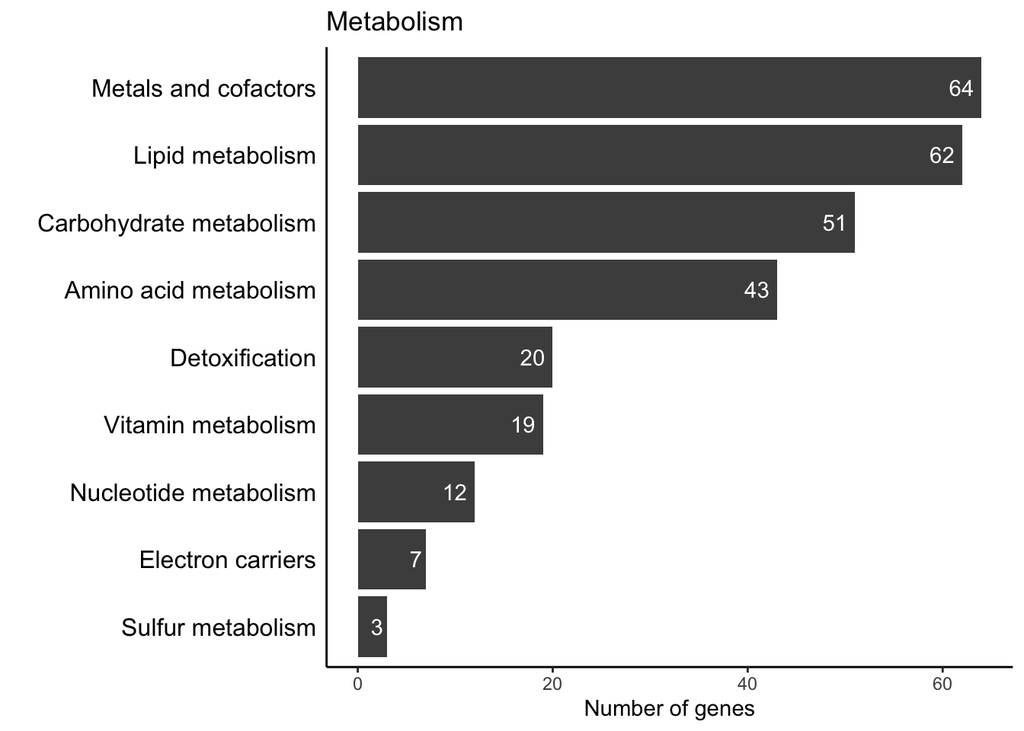

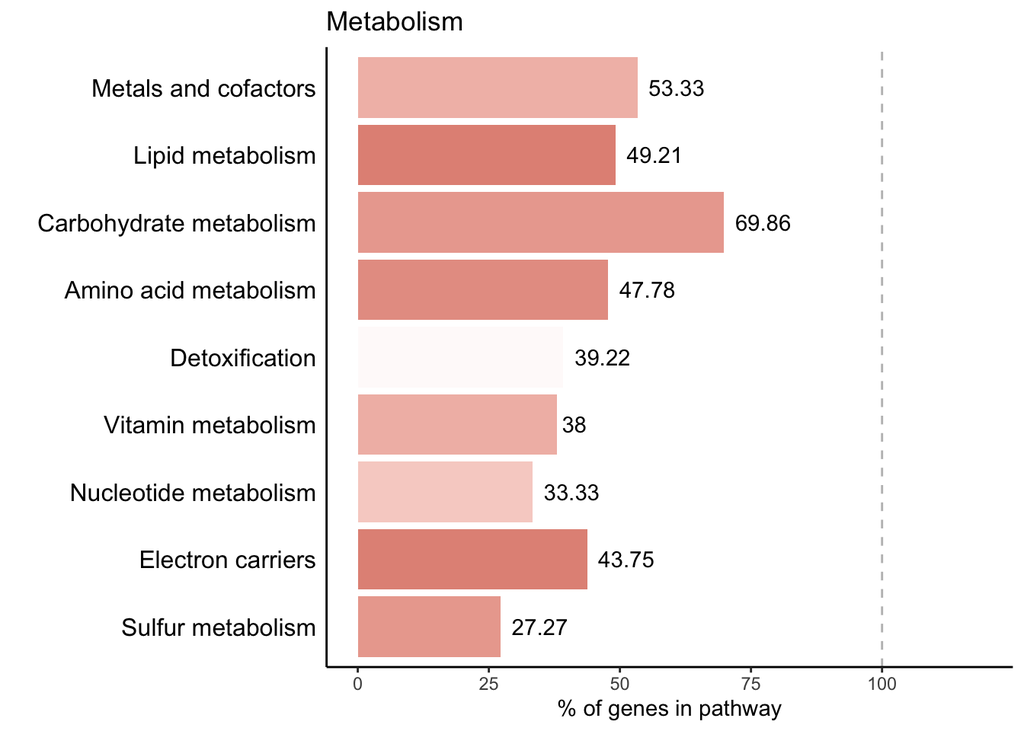

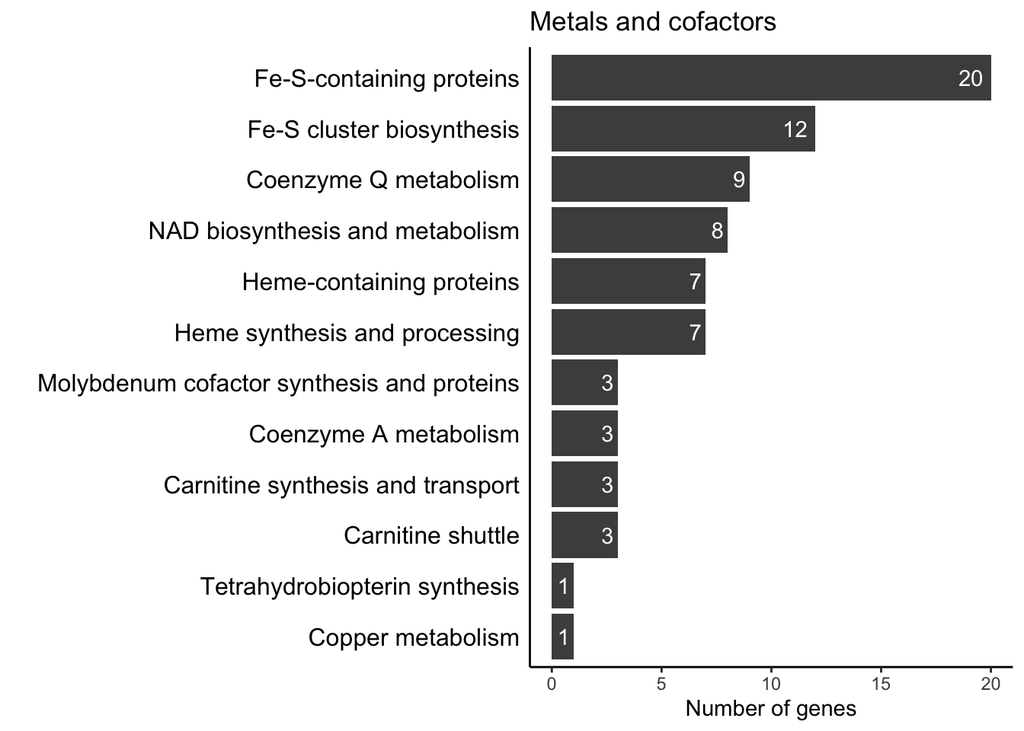

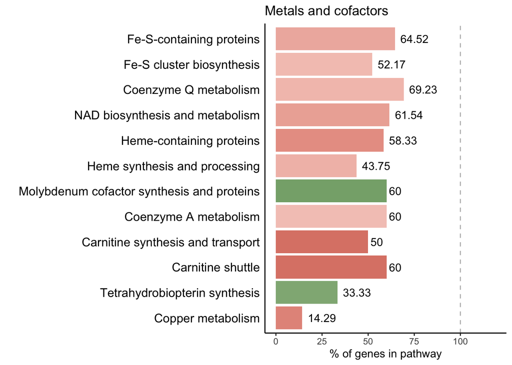

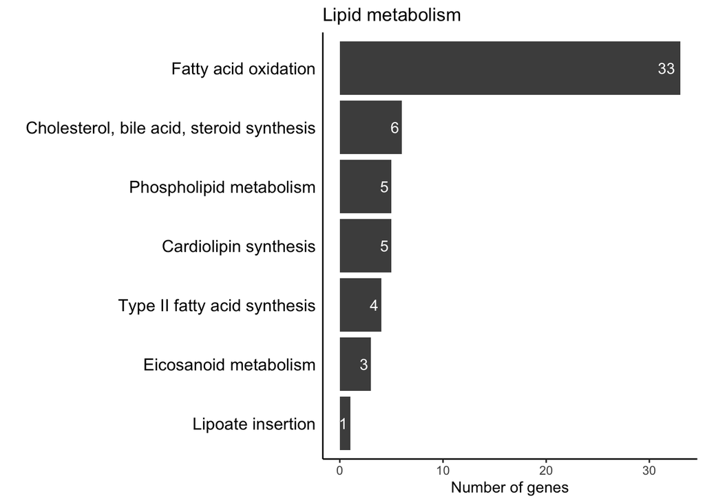

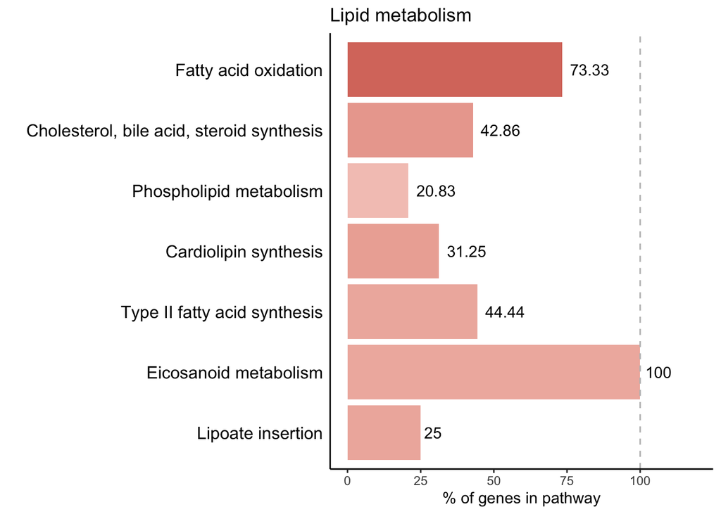

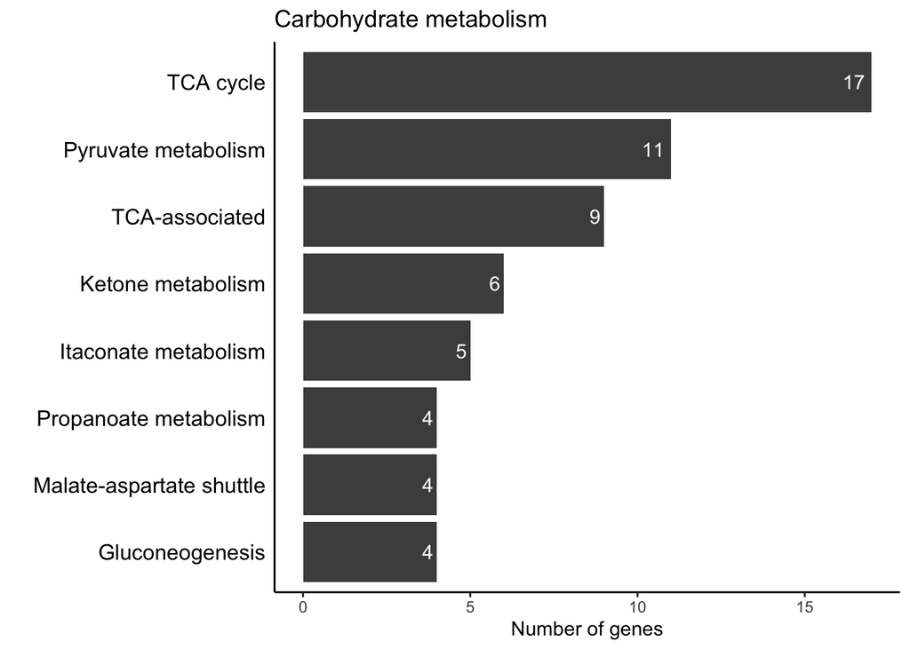

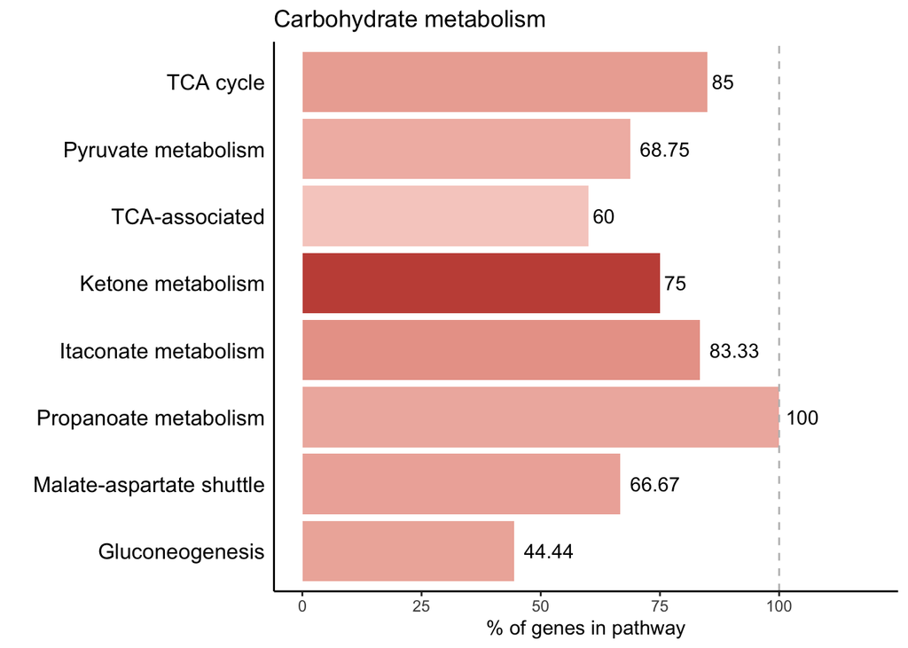

[2 more figures not shown]

```r
##################################################
##                                              ##
##    User-friendly function for graphing       ##
##     the number of genes in a filtered        ##
##    dataset or the percentage of genes in     ##
##   in this dataset that occupy a pathway      ##
##                                              ##
##################################################

bar_graphs_mitocarta <- list()

for(plot_name in c("Primary","OXPHOS","Metabolism","Metals and cofactors",
              "Lipid metabolism", "Carbohydrate metabolism", "Amino acid metabolism")){

  temp_plot <- plot_mitocarta_pathways(filtered_data = data_filtered,
                          mitocarta_data = mitocarta_data,
                          subpath = plot_name,
                          fc_name = "log2FC_mean")

  bar_graphs_mitocarta[[plot_name]] <- temp_plot

  print(temp_plot[["GeneNumber"]])
  temp_plot_no_legend <- temp_plot[["PathwayPercent"]] + ggplot2::theme(legend.position = "none")
  print(temp_plot_no_legend)

}
```

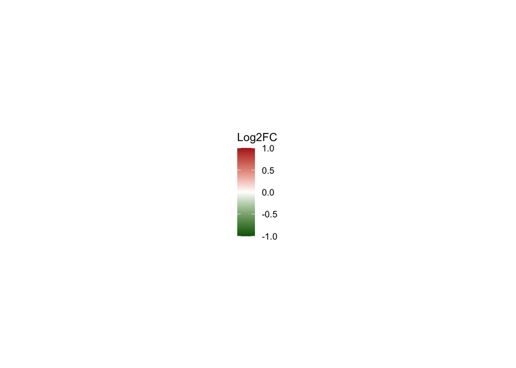

```r
  logFC_legend <- cowplot::get_legend(temp_plot[["PathwayPercent"]])
  grid.newpage()
  grid.draw(logFC_legend)
```

## Gene Expression Heatmap for Specific Pathways (Figure 2)

Here, we generate the heatmaps showing the logFC with indicated significant for both the male and female datasets for the pathways indicated in the for-loop. These heatmaps plot all the genes associated with the grepped path name. They are stored in a list item (not printed).

```r
mito_heatmaps <- list()

plot_data <- mitocarta_data[["MitoCarta_MitoGenes"]] %>%

  # Select MitoCarta gene names and their pathways
  dplyr::select(Name,Pathways) %>%
  dplyr::rename(mitocarta_id = Name) %>%

  # For this study, join with the list of checked gene symbols
  dplyr::left_join(., gene_names_checked, by = "mitocarta_id") %>%
  stats::na.omit() %>%
  dplyr::rename(external_gene_name = given_id) %>%

  # For this study, join with gene list with genes row bound by sex
  dplyr::left_join(line_genes_by_sex, ., by = "external_gene_name") %>%

  # Any genes that are missing a Significance identifier, mark as not Significant
  dplyr::mutate(Significant = ifelse(is.na(Significant),"No",Significant))


for(subpath in c("OXPHOS","Fatty acid oxidation","TCA","Pyruvate metabolism")) {

plot_data_temp <- plot_data %>%
  filter(grepl(subpath, Pathways)) %>%
  filter(external_gene_name != "",external_gene_name != ".") %>%
  group_by(external_gene_name, Sex) %>%
  slice_head(n=1)

ynames <- plot_data_temp %>% arrange(external_gene_name) %>% pull(external_gene_name)

p <- ggplot(plot_data_temp) +
  geom_tile(aes(fill=log2FoldChange, y=external_gene_name, x=Sex, color=Significant),
                width=0.90,height=1.65, linewidth = 0.3) +
  scale_fill_gradient2("Log2FC",low="darkgreen",
                       mid = "white",
                       high = "firebrick",
                       midpoint = 0,
                       limits = c(-2.3,2.3)) +
  scale_color_manual(values = c("white","black")) +
  scale_y_discrete(limits = rev(ynames)) +
  ggtitle(subpath) +
  ylab("") +
  xlab("") +
  theme(axis.ticks =element_blank(),
        axis.text.x = element_text(angle=90),
        strip.text = element_text(size=10),
        axis.text.y = element_text(size=10),
        panel.background = element_blank())

mito_heatmaps[[subpath]] <- p

}
```